# Homework 2 - Decision Trees, Logistic Regression, and Support Vector Machines

#### Computing Bias

```python
# calculate bias helper function using kernel matrix
def calculate_bias(alpha, K, y, indices, C=1.0):
    # alpha denotes a vector of the alpha_i's or the lagrangian multipliers
    # K represents the precomputed kernel matrix
    # y represents the vector of target classifications
    # indices represents a vector of all the indexes corresponding to a support vector
    # C represents the regularization parameter

    bias_list = [] # Store list of biases
    margin_list = [] # Store list of margin SVs

    # Loop through SVs and obtain all indices of margin support vectors
    for index in indices:
        if alpha[index] > 1e-5 and alpha[index] < C:
            margin_list.append(index)

    # Catch if no margin support vectors; Claude suggestion
    if len(margin_list) == 0:
        margin_list = indices

    # # Loop through and calculate Bias = y_i - Sum(a_j * y_j * K[i,j])
    # for index in margin_list:

    #     # Calculate sum_term
    #     sum_term = 0.0
    #     for j in indices:
    #         sum_term += alpha[j] * y[j] * K[index,j]

    #     # Calculate b = y - sum_term
    #     b_i = y[index] - sum_term
    #     bias_list.append(b_i)



    # Compute bias for all margin SVs at once using vectorization; Claude

    # Extract relevant rows from kernel matrix for margin support vectors
    K_margin = K[margin_list][:, indices]  # Shape: (n_margin_svs, n_svs)

    # Compute sum_j(alpha_j * y_j * K[i,j]) for all margin SVs simultaneously
        # alpha[indices] * y[indices] gives vector of (alpha_j * y_j) for all SVs
        # K_margin @ (alpha[indices] * y[indices]) computes the sum for each margin SV
    sum_terms = np.dot(K_margin, alpha[indices] * y[indices])

    # Compute b_i = y_i - sum_term for all margin SVs
    bias_values = y[margin_list] - sum_terms

    return np.mean(bias_values)  # Return average of SV biases
```

#### Prediction

```python
# We make predictions based on the data points from a test set using vectorized operations; Claude assistance
def predict(model, X_new):
    # model is a dictionary containing all of information of our fitted SVM
         # alpha[indices] are all the alpha_i's of support vectors
         # sv is X[indices] are a matrix consisting of all support vector x_i's
         # sv_labels is y[indices], the labels of our SVs
         # bias is the model bias
         # kernel_type is the kernel
         # C is the regularization parameter
         # gamma is the hyperparameter for RBF Kernel
    # X_new is the data matrix we want to predict on (n_samples, n_features)

    alphas = model['alpha']  # Alpha values for support vectors
    sv = model['sv']  # The actual support vector points (n_sv, n_features)
    sv_labels = model['sv_labels']  # Labels of support vectors
    bias = model['bias']
    kernel_type = model['kernel_type']
    gamma = model['gamma']

    # Compute kernel matrix between test points and support vectors
    if kernel_type == 'linear':
        # For linear kernel: K[i,j] = X_new[i] · sv[j]
        # Vectorized as X_new @ sv.T
        K_test = np.dot(X_new, sv.T)

    elif kernel_type == 'rbf':
        # For RBF kernel: K[i,j] = exp(-gamma * ||X_new[i] - sv[j]||^2)
        # Using the expansion: ||a - b||^2 = ||a||^2 + ||b||^2 - 2*a·b

        # Compute squared norms for test points: ||X_new[i]||^2
        sq_norms_new = np.sum(X_new ** 2, axis=1).reshape(-1, 1)

        # Compute squared norms for support vectors: ||sv[j]||^2
        sq_norms_sv = np.sum(sv ** 2, axis=1).reshape(1, -1)

        # Broadcasting computes all pairwise squared distances at once
        sq_dists = sq_norms_new + sq_norms_sv - 2 * np.dot(X_new, sv.T)

        # Apply RBF transformation
        K_test = np.exp(-gamma * sq_dists)

    else:
        raise ValueError("Current kernel type not supported!")

    # Compute decision function for all test points at once
        # decision[i] = bias + sum_j(alpha_j * y_j * K[i,j])
        # This is equivalent to: bias + K_test @ (alphas * sv_labels)
        # where @ is matrix multiplication and * is element-wise multiplication

    # Element-wise multiplication of alphas with labels
    alpha_y = alphas * sv_labels

    # Matrix-vector multiplication computes sum for all test points simultaneously
    decisions = bias + np.dot(K_test, alpha_y)

    # Convert decision values to class predictions {-1, +1}
    predictions = np.where(decisions >= 0, 1, -1)

    return predictions  # Return numpy array of predictions
```

### Application & Evaluation

Now, we apply our functions to the UCI Breast Cancer data set!

#### Data Loading and Preprocessing

For this task, we'll use the same UCI Breast Cancer Wisconsin Dataset from Task 2. However, SVMs conventionally use labels of -1 and +1 instead of 0 and 1, so we'll encode malignant tumors as +1 and benign as -1. Additionally, the homework specifies a 70/30 train/test split for SVMs (no validation set needed since we're not doing early stopping), and we'll normalize our features to ensure the SVM optimization converges properly.

```python
# # This code is copied directly from the UCI ML Repository "Import [data] in Python"

# # Fetch Breast Cancer Dataset using UCIMLREPO library
# breast_cancer_data = fetch_ucirepo(id=17)

# # data (as pandas dataframes)
# X = breast_cancer_data.data.features
# y = breast_cancer_data.data.targets

# Load Car Evaluation Dataset from GitHub as there are issues with SSL
url = "https://raw.githubusercontent.com/JZhong01/FRE7773-MLinFE/refs/heads/main/wdbc.data"
column_names = ['ID','Diagnosis','radius1','texture1','perimeter1','area1','smoothness1',
               'compactness1','concavity1','concave_points1','symmetry1','fractal_dimension1',
                'radius2','texture2','perimeter2','area2','smoothness2',
               'compactness2','concavity2','concave_points2','symmetry2','fractal_dimension2',
                'radius3','texture3','perimeter3','area3','smoothness3',
               'compactness3','concavity3','concave_points3','symmetry3','fractal_dimension3'
               ]

# Read the data
data = pd.read_csv(url, names=column_names)

# Split into features (X) and target (y)
X = data.drop(['ID','Diagnosis'], axis=1)
y = data[['Diagnosis']]


print(X)
print(y)

# # variable information
# print(breast_cancer_data.variables)
```

```
     radius1  texture1  perimeter1   area1  smoothness1  compactness1  \
0      17.99     10.38      122.80  1001.0      0.11840       0.27760
1      20.57     17.77      132.90  1326.0      0.08474       0.07864
2      19.69     21.25      130.00  1203.0      0.10960       0.15990
3      11.42     20.38       77.58   386.1      0.14250       0.28390
4      20.29     14.34      135.10  1297.0      0.10030       0.13280
..       ...       ...         ...     ...          ...           ...
564    21.56     22.39      142.00  1479.0      0.11100       0.11590
565    20.13     28.25      131.20  1261.0      0.09780       0.10340
566    16.60     28.08      108.30   858.1      0.08455       0.10230
567    20.60     29.33      140.10  1265.0      0.11780       0.27700
568     7.76     24.54       47.92   181.0      0.05263       0.04362

     concavity1  concave_points1  symmetry1  fractal_dimension1  ...  radius3  \
0       0.30010          0.14710     0.2419             0.07871  ...   25.380
```

[output cut: 52 more lines]

```python
y_new = [] # new array of our target variable

# Logic to convert every 'M' in target array to 1 and 'B' to -1
for i in range(len(y)):
    if y.iloc[i, 0] == 'M':
        y_new.append(1)  # Malignant
    else:
        y_new.append(-1) # Benign

# Convert DataFrames to numpy arrays
X_array = X.values  # Convert feature DataFrame to numpy array
y_array = np.array(y_new)  # Convert binary list to numpy array

# print(y_new)
```

```python
# Train/test split function (70/30 for SVM), adjusted from previous tasks
def train_test_split_svm(X, y, train_ratio=0.70, random_seed=None):
    # X represents the feature matrix size number of samples by number of features
    # y represents the target vector with length equal to number of samples
    # train_ratio represents the proportion of data allocated to training set
    # random_seed is an optional parameter for reproducibility


    # Set random seed if provided for reproducibility
    if random_seed is not None:
        np.random.seed(random_seed)

    n = X.shape[0]  # Total number of samples

    # Create array of indices from 0 to n-1 and shuffle them randomly
    indices = np.arange(n)
    np.random.shuffle(indices)  # In-place randomization

    # Calculate the split points based on ratios
        # Remaining samples go to test set
    train_end = int(n * train_ratio)

    # Split the indices into two groups
    train_indices = indices[:train_end]
    test_indices = indices[train_end:]

    # Apply the shuffled indices to X and y to create the splits
    X_train = X[train_indices]
    X_test = X[test_indices]
    y_train = y[train_indices]
    y_test = y[test_indices]

    return X_train, X_test, y_train, y_test   # Outputs the split datasets according to shuffled indices where X and y rows align
```

```python
# Perform train/test split
random.seed(234)
np.random.seed(234)
X_train, X_test, y_train, y_test = train_test_split_svm(X_array, y_array, random_seed=234)
```

```python
# Function to normalize features, slightly modified from version in Task 2
def normalize_features_svm(X_train, X_test):
    # X_train represents training features
    # X_test represents test features

    n_train = X_train.shape[0]
    n_features = X_train.shape[1]

    # Calculate means from training data only
    means = np.zeros(n_features)
    for j in range(n_features):
        feature_sum = 0.0
        for i in range(n_train):
            feature_sum += X_train[i, j]
        means[j] = feature_sum / n_train

    # Calculate standard deviations from training data only
    stds = np.zeros(n_features)
    for j in range(n_features):
        squared_diff_sum = 0.0
        for i in range(n_train):
            diff = X_train[i, j] - means[j]
            squared_diff_sum += diff * diff
        variance = squared_diff_sum / n_train
        stds[j] = np.sqrt(variance)

    # Normalize training set
    X_train_norm = np.zeros_like(X_train)
    for j in range(n_features):
        for i in range(n_train):
            if stds[j] > 1e-8:
                X_train_norm[i, j] = (X_train[i, j] - means[j]) / stds[j]
            else:
                X_train_norm[i, j] = 0.0

    # Normalize test set using training statistics to avoid data leakage
    n_test = X_test.shape[0]
    X_test_norm = np.zeros_like(X_test)
    for j in range(n_features):
        for i in range(n_test):
            if stds[j] > 1e-8:
                X_test_norm[i, j] = (X_test[i, j] - means[j]) / stds[j]
            else:
                X_test_norm[i, j] = 0.0

    return X_train_norm, X_test_norm   # Outputs both normalized datasets
```

```python
# Normalize the data
X_train_norm, X_test_norm = normalize_features_svm(X_train, X_test) # returns the normalized data
```

#### Training SVM with different Hyperparameters

We'll train multiple SVM models with different hyperparameter configurations to understand how C (regularization) and gamma (RBF kernel width) affect performance. For linear kernels, we'll vary C to see the trade-off between margin width and training accuracy. For RBF kernels, we'll vary both C and gamma to explore their combined effects on decision boundary complexity.

```python
# Train Linear SVM with C=0.1

model_linear_c01 = fit_optimized(X_train_norm, y_train,
                       kernel_type='linear',
                       C=0.1,
                       gamma=0.1)
```

```python
# Train Linear SVM with C=1.0

model_linear_c10 = fit_optimized(X_train_norm, y_train,
                       kernel_type='linear',
                       C=1.0,
                       gamma=0.1)
```

```python
# Train Linear SVM with C=10.0

model_linear_c100 = fit_optimized(X_train_norm, y_train,
                       kernel_type='linear',
                       C=10.0,
                       gamma=0.1)
```

```python
# Train RBF SVM with C=1.0, gamma=0.01

model_rbf_c10_g001 = fit_optimized(X_train_norm, y_train,
                         kernel_type='rbf',
                         C=1.0,
                         gamma=0.01)
```

```python
# Train RBF SVM with C=1.0, gamma=0.1

model_rbf_c10_g01 = fit_optimized(X_train_norm, y_train,
                         kernel_type='rbf',
                         C=1.0,
                         gamma=0.1)
```

```python
# Train RBF SVM with C=1.0, gamma=1.0

model_rbf_c10_g10 = fit_optimized(X_train_norm, y_train,
                         kernel_type='rbf',
                         C=1.0,
                         gamma=1.0)
```

#### Evaluating Performance

We'll now evaluate our best-performing SVM model using comprehensive metrics: accuracy, precision, recall, F1-score, and ROC-AUC. We'll also create a confusion matrix to visualize the types of errors our model makes. These are the same evaluation metrics we used in Task 2, allowing for direct comparison between our SVM and logistic regression implementations.

We need to convert our SVM predictions from {-1, +1} format to {0, 1} format to use the evaluation functions from Task 2. We'll evaluate all models.

```python
# Function to compute decision scores for ROC curve
def predict_scores(model, X_new):
    # model is a dictionary containing all of information of our fitted SVM
         # alpha[indices] are all the alpha_i's of support vectors
         # sv is X[indices] are a matrix consisting of all support vector x_i's
         # sv_labels is y[indices], the labels of our SVs
         # bias is the model bias
         # kernel_type is the kernel
         # C is the regularization paramter
         # gamma is the hyperparamter for RBF Kernel
    # X_new represents new data points to score

    # Extract values from model dictionary
    alphas = model['alpha']
    sv = model['sv']
    sv_labels = model['sv_labels']
    bias = model['bias']
    kernel_type = model['kernel_type']
    gamma = model['gamma']

    scores = []  # empty array to store decision scores for each point

    # loop through every point in testing data
    for current_pt in X_new:

        decision_sum = bias  # Track f(current_pt)

        # loop to sum a_i * y_i * K(x_i,x_new)
        for i in range(len(sv)):
            decision_sum += alphas[i] * sv_labels[i] * kernel(sv[i], current_pt, kernel_type, gamma)

        # Store decision score to vector
        scores.append(decision_sum)

    return np.array(scores)  # return vector of decision scores
```

```python
# Function to evaluate SVM model performance using Model Evaluation functions from Task 2
    # We do need to change both the predicted and actual y's to {0,1} from {-1,1} to reuse
def evaluate_svm_model(model, X_test, y_test):
    # model is the trained SVM model dictionary
    # X_test represents the test features
    # y_test represents the test labels in {-1, +1} format

    # Make predictions on test set
    y_test_pred = predict(model, X_test)

    # Get decision scores for ROC-AUC calculation
    y_test_scores = predict_scores(model, X_test)

    # Convert SVM predictions from {-1, +1} to {0, 1} in order to use Task 2's metric functions
    final_y_pred = np.zeros(len(y_test_pred))
    for i in range(len(y_test_pred)):
        if y_test_pred[i] == 1:
            final_y_pred[i] = 1
        else:
            final_y_pred[i] = 0

    final_y_pred = final_y_pred.astype(int) # Cast back to int; Claude

    # Convert test labels from {-1, +1} to {0, 1}
    y_test_binary = np.zeros(len(y_test))
    for i in range(len(y_test)):
        if y_test[i] == 1:
            y_test_binary[i] = 1
        else:
            y_test_binary[i] = 0

    y_test_binary = y_test_binary.astype(int) # Cast back to int; Claude

    # Calculate all evaluation metrics
    accuracy = compute_accuracy(y_test_binary, final_y_pred)
    precision = compute_precision(y_test_binary, final_y_pred)
    recall = compute_recall(y_test_binary, final_y_pred)
    f1 = compute_f1_score(y_test_binary, final_y_pred)
    roc_auc = compute_roc_auc(y_test_binary, y_test_scores)
    cm = compute_confusion_matrix(y_test_binary, final_y_pred)


    # Print results
    print("Test Set Evaluation Results:")
    print("Accuracy: ", accuracy)
    print("Precision: ", precision)
    print("Recall: ", recall)
    print("F1-Score: ", f1)
    print("ROC-AUC: ", roc_auc)
    print("Confusion Matrix: \n", cm)
```

```python
print("Linear SVM with C=0.1")
results_linear_c01 = evaluate_svm_model(model_linear_c01, X_test_norm, y_test)
```

```
Linear SVM with C=0.1
Test Set Evaluation Results:
Accuracy:  0.9824561403508771
Precision:  0.96875
Recall:  0.9841269841269841
F1-Score:  0.9763779527559054
ROC-AUC:  0.9970605526161083
Confusion Matrix:
 [[106.   2.]
 [  1.  62.]]
```

```python
print("Linear SVM with C=1.0")
results_linear_c10 = evaluate_svm_model(model_linear_c10, X_test_norm, y_test)
```

```
Linear SVM with C=1.0
Test Set Evaluation Results:
Accuracy:  0.9707602339181286
Precision:  0.967741935483871
Recall:  0.9523809523809523
F1-Score:  0.96
ROC-AUC:  0.9945620223398002
Confusion Matrix:
 [[106.   2.]
 [  3.  60.]]
```

```python
print("Linear SVM with C=10.0")
results_linear_c100 = evaluate_svm_model(model_linear_c100, X_test_norm, y_test)
```

```
Linear SVM with C=10.0
Test Set Evaluation Results:
Accuracy:  0.9766081871345029
Precision:  0.9682539682539683
Recall:  0.9682539682539683
F1-Score:  0.9682539682539683
ROC-AUC:  0.9878012933568492
Confusion Matrix:
 [[106.   2.]
 [  2.  61.]]
```

```python
print("RBF SVM with C=1.0, gamma=0.01")
results_rbf_c10_g001 = evaluate_svm_model(model_rbf_c10_g001, X_test_norm, y_test)
```

```
RBF SVM with C=1.0, gamma=0.01
Test Set Evaluation Results:
Accuracy:  0.9824561403508771
Precision:  0.96875
Recall:  0.9841269841269841
F1-Score:  0.9763779527559054
ROC-AUC:  0.9967666078777191
Confusion Matrix:
 [[106.   2.]
 [  1.  62.]]
```

```python
print("RBF SVM with C=1.0, gamma=0.1")
results_rbf_c10_g01 = evaluate_svm_model(model_rbf_c10_g01, X_test_norm, y_test)
```

```
RBF SVM with C=1.0, gamma=0.1
Test Set Evaluation Results:
Accuracy:  0.9473684210526315
Precision:  0.8857142857142857
Recall:  0.9841269841269841
F1-Score:  0.9323308270676691
ROC-AUC:  0.9945620223398002
Confusion Matrix:
 [[100.   8.]
 [  1.  62.]]
```

```python
print("RBF SVM with C=1.0, gamma=1.0")
results_rbf_c10_g10 = evaluate_svm_model(model_rbf_c10_g10, X_test_norm, y_test)
```

```
RBF SVM with C=1.0, gamma=1.0
Test Set Evaluation Results:
Accuracy:  0.6374269005847953
Precision:  1.0
Recall:  0.015873015873015872
F1-Score:  0.03125
ROC-AUC:  0.9541446208112878
Confusion Matrix:
 [[108.   0.]
 [ 62.   1.]]
```

Comparing our best linear model (C=0.1) with our best RBF model (C=1.0, gamma=0.01), we see nearly identical performance (both F1=97.64%). This suggests the decision boundary that separates malignant from benign tumors is approximately linear in the original 30-dimensional feature space.

The linear kernel creates a single flat hyperplane that divides the space, while RBF with small gamma creates a smooth, gently curved surface. When these achieve the same performance, it indicates the data is linearly separable and doesn't require the additional flexibility of non-linear SVMs. The RBF kernel's ability to create complex, curved boundaries provides no advantage for this dataset and actually introduces the risk of catastrophic overfitting if gamma isn't tuned properly.

### Analysis

So now that we've come up with our chosen model for predicting breast cancer, we will go into further analysis into how the hyperparameters affected our SVM models, visualize our support vectors and decision boundaries, as well as compare how our RBF SVM model compares to Scikit-Learn's SVM and our previous Logistic Regression model.

#### How different hyperparameters affect decision boundaries

The regularization parameter C controls the trade-off between achieving a wide margin and correctly classifying training points. Geometrically, C determines how much we penalize misclassifications during training.

When C is small (like C=0.1), we prioritize having a wide margin between classes, even if that means some training points fall on the wrong side of the margin or are misclassified. This creates a "soft margin" that's more tolerant of outliers and noise in the training data. The decision boundary tends to be smoother and more generalizable because the model doesn't contort itself to fit every single training point perfectly.

When C is large (like C=10.0), we heavily penalize any misclassifications, forcing the model to work harder to correctly classify every training point. This creates a "hard margin" where the decision boundary can become more complex and irregular as it bends around individual points. While this achieves higher training accuracy, it risks overfitting to noise in the training data.

For our linear kernel results, we saw this firsthand as C=0.1 achieved the best test performance (F1=97.64%), while C=1.0 and C=10.0 performed slightly worse. However, for the purposes of balancing concerns of overfitting and underfitting, we chose C=1.0 as a "balanced" hyperparameter value when fitting for our non-linear RBF SVM.

*************************************

The gamma parameter in RBF kernels controls the "reach" or "influence" of each support vector. Geometrically, each support vector creates a Gaussian "bump" in the feature space, and gamma determines the width of these bumps.

When gamma is small (like gamma=0.01), each support vector influences points far away from it. The Gaussian bumps are wide and overlap significantly, creating smooth, gradual transitions in the decision boundary. This is similar to having a "global" view where the model considers broader patterns in the data.

When gamma is large (like gamma=1.0), each support vector only influences points very close to it. The Gaussian bumps are narrow and isolated, creating sharp, localized peaks in the feature space. This is similar to having a "local" view where the model focuses intensely on individual points.

Mathematically, recall that the RBF kernel is: $K(x_i, x_j) = \exp(-\gamma ||x_i - x_j||^2)$

When $\gamma$ is large, the exponential term becomes very small (close to zero). This means points need to be extremely close to a support vector to be influenced by it. The decision boundary becomes a collection of tiny "islands" around each support vector rather than a smooth, continuous surface.

We see this play out as we increase the value of Gamma:

- Gamma=0.01: Wide bumps create smooth boundaries and good generalization (F1=97.64%, Recall=98.41%)
- Gamma=0.1: Medium bumps create more complex boundaries, which slightly degraded performance (F1=93.23%, Recall=98.41%)
- Gamma=1.0: Narrow bumps fragment the space, leading to abysmal performance and catastrophic failure (F1=3.13%, Recall=1.59%)

#### Visualize support vectors and decision boundaries

To visualize our SVM decision boundaries and support vectors, we will reduce our 30-dimensional feature space down to 2 dimensions. We accomplish this using Principal Component Analysis (PCA), which identifies the two directions in our data that capture the most variance. By projecting our data onto these two principal components, we can create 2D visualizations while preserving as much information as possible about the structure and separability of our classes.

```python
# Function to perform PCA using SVD method; Claude assistance
def compute_pca(data, n_components=2):
    # data represents the input matrix
    # n_components is the number of principal components to keep


    # Calculate mean for each feature
    col_mean = np.mean(data, axis=0)

    # Calculate standard deviation for each feature
    col_std = np.std(data, axis=0)

    # Standardize: (X - mu) / sigma
    standardized_data = (data - col_mean) / col_std


    # SVD decomposes X = U @ S @ V.T
    # V contains our principal components (no covariance matrix needed!)
    U, singular_values, VT = np.linalg.svd(standardized_data, full_matrices=False)


    # VT has principal components as rows, we want them as columns
    principal_components = VT.T

    # Select top n_components
    components_subset = principal_components[:, 0:n_components]

    # Project data onto principal components
    projected_data = np.dot(standardized_data, components_subset)

    # Eigenvalues = (singular_values^2) / (n_samples - 1)
    n_samples = data.shape[0]
    eigenvalues = (singular_values ** 2) / (n_samples - 1)

    # Calculate explained variance
    total_variance = np.sum(eigenvalues)
    explained_variance = eigenvalues / total_variance
    cumulative_variance = np.cumsum(explained_variance)


    return projected_data, components_subset, col_mean, col_std
```

```python
# Apply PCA to reduce training data to 2 dimensions
X_train_2d, components, train_mean, train_std = compute_pca(X_train_norm, n_components=2)

# Transform test data using the same principal components from training
# This ensures consistency and avoids data leakage
X_test_standardized = (X_test_norm - train_mean) / train_std
X_test_2d = np.dot(X_test_standardized, components)
```

We now train each of our SVM configurations on the 2D projected data. Note that the performance on this reduced data will be lower than our full 30-dimensional models since we're only capturing a portion of the total variance. However, this 2D representation allows us to visualize the decision boundaries, support vectors, and how different hyperparameters affect the geometry of the classification boundary.

```python
# Train Linear SVM with C=0.1 on 2D projected data
model_2d_linear_c01 = fit_optimized(X_train_2d, y_train,
                                     kernel_type='linear',
                                     C=0.1,
                                     gamma=0.1)

# Train RBF SVM with C=1.0, gamma=0.01 on 2D projected data
model_2d_rbf_c10_g001 = fit_optimized(X_train_2d, y_train,
                                       kernel_type='rbf',
                                       C=1.0,
                                       gamma=0.01)
```

```python
# Function to visualize SVM decision boundary and support vectors in 2D; Heavy Claude Assistance
def plot_svm_decision_boundary(model, X_train, y_train, title):
    # model is the trained SVM model dictionary
    # X_train is the 2D training data
    # y_train is the training labels in {-1, +1} format
    # title is the plot title string

    # Determine the bounds of our plot based on training data
    x_min = X_train[:, 0].min() - 1
    x_max = X_train[:, 0].max() + 1
    y_min = X_train[:, 1].min() - 1
    y_max = X_train[:, 1].max() + 1

    # Create a mesh grid with fine spacing
    h = 0.02  # Step size in the mesh
    xx_vals = np.arange(x_min, x_max, h)
    yy_vals = np.arange(y_min, y_max, h)

    # Create meshgrid from x and y values
    xx, yy = np.meshgrid(xx_vals, yy_vals)

    # Flatten the grid to pass through predict function
    grid_points = np.c_[xx.ravel(), yy.ravel()]

    # Get predictions for all grid points
    Z = predict(model, grid_points)

    # Convert predictions list to numpy array
    Z = np.array(Z)

    # Reshape predictions back to grid shape for plotting
    Z = Z.reshape(xx.shape)

    # Create the plot
    plt.figure(figsize=(10, 8))

    # Plot decision regions with color fill
    # Benign region (class -1) in light blue, Malignant region (class +1) in light coral
    plt.contourf(xx, yy, Z, alpha=0.3, levels=[-1, 0, 1], colors=['lightblue', 'lightcoral'])

    # Plot decision boundary as a thick black line where Z=0
    plt.contour(xx, yy, Z, levels=[0], colors='black', linewidths=2)

    # Plot training points
    for i in range(len(X_train)):
        if y_train[i] == 1:
            # Malignant samples as red circles
            plt.scatter(X_train[i, 0], X_train[i, 1], c='red', marker='o', s=50, edgecolors='k', linewidths=1)
        else:
            # Benign samples as blue squares
            plt.scatter(X_train[i, 0], X_train[i, 1], c='blue', marker='s', s=50, edgecolors='k', linewidths=1)

    # Highlight support vectors with larger yellow circles
    sv = model['sv']
    sv_labels = model['sv_labels']

    for i in range(len(sv)):
        plt.scatter(sv[i, 0], sv[i, 1], c='none', s=200,
                   edgecolors='yellow', linewidths=3, alpha=0.8)

    plt.xlabel('First Principal Component', fontsize=12)
    plt.ylabel('Second Principal Component', fontsize=12)
    plt.title(title, fontsize=14)
    plt.grid(True, alpha=0.3)

    # Create legend
    from matplotlib.patches import Patch
    legend_elements = [
        Patch(facecolor='lightcoral', edgecolor='black', label='Malignant Region'),
        Patch(facecolor='lightblue', edgecolor='black', label='Benign Region'),
        plt.Line2D([0], [0], marker='o', color='w', markerfacecolor='red',
                   markersize=10, markeredgecolor='k', label='Malignant Training'),
        plt.Line2D([0], [0], marker='s', color='w', markerfacecolor='blue',
                   markersize=10, markeredgecolor='k', label='Benign Training'),
        plt.Line2D([0], [0], marker='o', color='w', markerfacecolor='none',
                   markersize=15, markeredgecolor='yellow', markeredgewidth=3, label='Support Vector')
    ]
    plt.legend(handles=legend_elements, loc='best', fontsize=10)

    plt.tight_layout()
    plt.show()
```

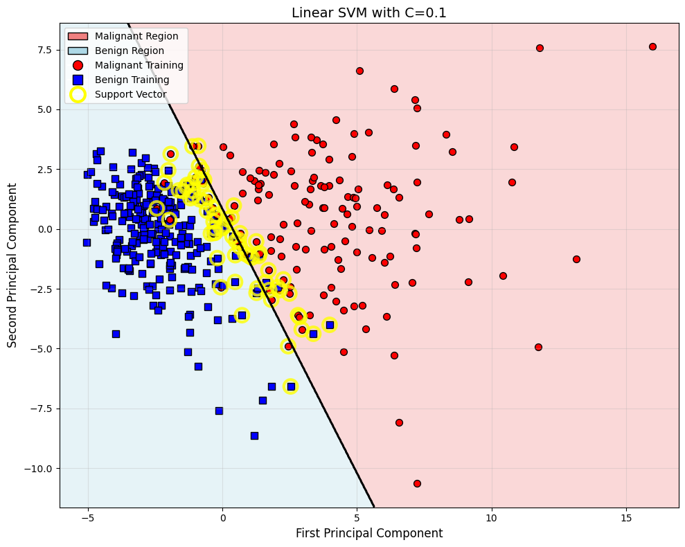

```python
# Visualize Linear SVM with C=0.1
plot_svm_decision_boundary(model_2d_linear_c01, X_train_2d, y_train,
                           'Linear SVM with C=0.1')
```

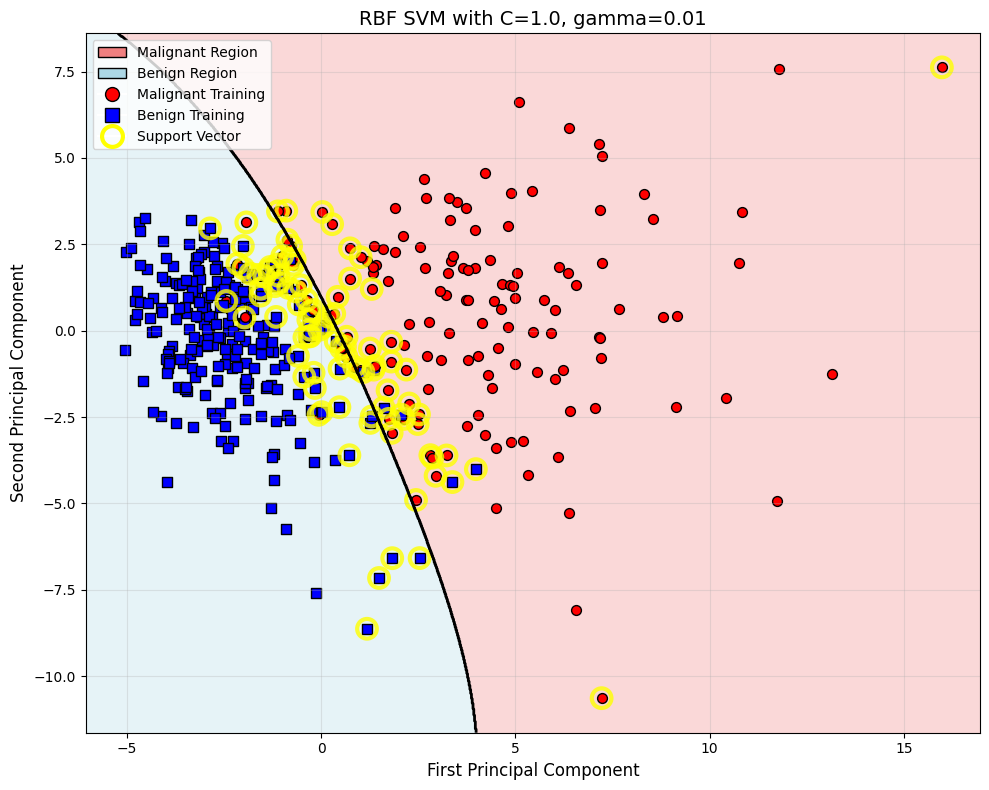

```python
# Visualize RBF SVM with C=1.0, gamma=0.01
plot_svm_decision_boundary(model_2d_rbf_c10_g001, X_train_2d, y_train,
                           'RBF SVM with C=1.0, gamma=0.01')
```

#### Compare implementation with Scikit-Learn's SVM

We'll now benchmark our from-scratch SVM implementation against scikit-learn's optimized SVC (Support Vector Classifier). This comparison will evaluate both performance metrics (accuracy, precision, recall, F1-score) and computational efficiency. Scikit-learn uses highly optimized code so it should train faster, but our hope is that our implementation should achieve comparable classification performance.

We'll test both linear and RBF kernels with the same hyperparameters we used earlier.

```python
from sklearn.svm import SVC
from sklearn.metrics import accuracy_score, precision_score, recall_score, f1_score, confusion_matrix, roc_auc_score

# Initialize and train sklearn's SVC with linear kernel C=0.1
sklearn_linear_c01 = SVC(kernel='linear', C=0.1, random_state=234)
sklearn_linear_c01.fit(X_train_norm, y_train)

# Make predictions on test set
y_pred_sklearn_linear = sklearn_linear_c01.predict(X_test_norm)

# Calculate all metrics using sklearn's functions
accuracy = accuracy_score(y_test, y_pred_sklearn_linear)
precision = precision_score(y_test, y_pred_sklearn_linear)
recall = recall_score(y_test, y_pred_sklearn_linear)
f1 = f1_score(y_test, y_pred_sklearn_linear)
cm = confusion_matrix(y_test, y_pred_sklearn_linear)

# For ROC-AUC, we need probability scores (decision_function works for SVM); Claude/Documentation
y_score_linear = sklearn_linear_c01.decision_function(X_test_norm)
roc_auc = roc_auc_score(y_test, y_score_linear)


# Print results
print("Test Set Evaluation Results for Sklearn Linear C=0.1:")
print("Accuracy: ", accuracy)
print("Precision: ", precision)
print("Recall: ", recall)
print("F1-Score: ", f1)
print("ROC-AUC: ", roc_auc)
print("Confusion Matrix: \n", cm)
```

```
Test Set Evaluation Results for Sklearn Linear C=0.1:
Accuracy:  0.9883040935672515
Precision:  0.9841269841269841
Recall:  0.9841269841269841
F1-Score:  0.9841269841269841
ROC-AUC:  0.9970605526161082
Confusion Matrix:
 [[107   1]
 [  1  62]]
```

```python
# Initialize and train sklearn's SVC with rbf kernel C=1.0, gamma=0.01
sklearn_rbf_c10_g001 = SVC(kernel='rbf', C=1.0, gamma=0.01, random_state=234)
sklearn_rbf_c10_g001.fit(X_train_norm, y_train)

# Make predictions on test set
y_pred_sklearn_rbf = sklearn_rbf_c10_g001.predict(X_test_norm)

# Calculate all metrics using sklearn's functions
accuracy = accuracy_score(y_test, y_pred_sklearn_rbf)
precision = precision_score(y_test, y_pred_sklearn_rbf)
recall = recall_score(y_test, y_pred_sklearn_rbf)
f1 = f1_score(y_test, y_pred_sklearn_rbf)
cm = confusion_matrix(y_test, y_pred_sklearn_rbf)

# For ROC-AUC
y_score_rbf = sklearn_rbf_c10_g001.decision_function(X_test_norm)
roc_auc = roc_auc_score(y_test, y_score_rbf)

# Print results
print("Test Set Evaluation Results for Sklearn RBF C=1.0, gamma=0.01:")
print("Accuracy: ", accuracy)
print("Precision: ", precision)
print("Recall: ", recall)
print("F1-Score: ", f1)
print("ROC-AUC: ", roc_auc)
print("Confusion Matrix: \n", cm)
```

```
Test Set Evaluation Results for Sklearn RBF C=1.0, gamma=0.01:
Accuracy:  0.9824561403508771
Precision:  0.96875
Recall:  0.9841269841269841
F1-Score:  0.9763779527559056
ROC-AUC:  0.996766607877719
Confusion Matrix:
 [[106   2]
 [  1  62]]
```

Some of the performance metrics were off by a little bit, but ultimately, my algorithm and code held its own. On speed and efficiency, however, it was significantly slower. Sci-kit learn's algorithm took a few seconds, and even with my vectorized computations, it still took anywhere from 10-30 seconds. (Don't even get me started with how much faster it was than my non-vectorized nested for loop implementation).

#### Compare implementation with previous Logistic Regression

If you recall, the evaluation performance metrics from the Logistic Regression were as follows:

Test Set Evaluation Results (Logistic Regression):  
Accuracy: 0.9767441860465116  
Precision: 1.0  
Recall: 0.9411764705882353  
F1-Score: 0.9696969696969697  
ROC-AUC: 0.9966063348416289

Now compare that to our Linear Kernel C=0.1 and RBF Kernel C=1.0, gamma=0.01 SVMs:

Linear SVM with C=0.1  
Test Set Evaluation Results:  
Accuracy: 0.9824561403508771  
Precision: 0.96875  
Recall: 0.9841269841269841  
F1-Score: 0.9763779527559054  
ROC-AUC: 0.9970605526161083  
Confusion Matrix:  
[[106. 2.]  
[ 1. 62.]]

RBF SVM with C=1.0, gamma=0.01  
Test Set Evaluation Results:  
Accuracy: 0.9824561403508771  
Precision: 0.96875  
Recall: 0.9841269841269841  
F1-Score: 0.9763779527559054  
ROC-AUC: 0.9967666078777191  
Confusion Matrix:  
[[106. 2.]  
[ 1. 62.]]

Both SVM models performed slightly better than our Logistic Regression. Now, this is most likely because the underlying data is linearly separable and thus could be split by a linear decision boundary. If our data didn't have this properties, then logistic regression and our Linear Kernel SVM wouldn't have performed as well as our RBF Kernel SVM.

## Sources Used

General:

- https://www.cmor-faculty.rice.edu/~heinken/latex/symbols.pdf

Decision Tree Classifier:

- https://www.deep-ml.com/problems/20
- https://www.deep-ml.com/problems/138
- https://claude.ai/share/05f41c27-53dd-4974-99bc-30eec58d4b44
- https://www.youtube.com/watch?v=NxEHSAfFlK8
- https://www.w3schools.com/python/python_dictionaries.asp

Logistic Regression:

- https://www.deep-ml.com/problems/104
- https://www.deep-ml.com/problems/106
- https://statisticalmusings.netlify.app/post/logistic-regression-mle-a-full-breakdown/
- https://www.w3schools.com/python/
- http://numpy.org/devdocs/reference/generated/numpy.matrix.html#
- https://scikit-learn.org/stable/modules/generated/sklearn.linear_model.LogisticRegression.html
- https://claude.ai/share/a59c38d8-0010-418e-8879-42b40db119b8

Support Vector Machines:

- https://www.geeksforgeeks.org/machine-learning/support-vector-machine-algorithm/
- https://www.youtube.com/watch?v=T9UcK-TxQGw
- https://claude.ai/chat/69223bee-e584-47f6-a1f5-acccb26a25e4
- https://docs.scipy.org/doc/scipy/tutorial/optimize.html#local-minimization-of-multivariate-scalar-functions-minimize
- https://www.geeksforgeeks.org/numpy/vectorized-operations-in-numpy/
- https://www.geeksforgeeks.org/machine-learning/gamma-parameter-in-svm/

### Disclosure

Claude was used for conceptual understanding and learning, but not for code. All code was written by myself unless noted otherwise (Although vectorizing was performed with the aid of AI) The Markdown explanations may be inspired in part by conversations with Claude (mainly the explanation for RBF Kernels), but never Copy-pasted.